# Solution

##### Module Code : CSMAD21

##### Assignment Report Title : Applied Data Science with Python Coursework

##### Date (Date when task was completed) : 8th December, 2023

##### Actual Hours Spent : 40 hours

# Task 1 - Bicycle Journerys : Exploratary Data Analysis

#### IMPORT MODULES IN PYTHON

```python
import pandas as pd  # importing module pandas which helps in data analysis of dataframe, series, etc
import numpy as np   # importing module numpy which helps in mathematical calculations on data.
import warnings     # this helps to handle any warnings in Python
import matplotlib.pyplot as plt  # importing module matplotlib.pyplot for data visualization
from datetime import date, timedelta  # import modules from datetime for handling date-related operations
from sklearn.metrics import silhouette_score  # import silhouette_score for evaluating clustering performance
from sklearn.cluster import KMeans  # import KMeans for k-means clustering algorithm
from pandas.plotting import scatter_matrix  # import scatter_matrix for creating scatter plots of features
from sklearn.mixture import GaussianMixture as GMM  # import GaussianMixture for Gaussian Mixture Model (GMM) clustering
from sklearn.metrics import rand_score  # import rand_score for evaluating clustering performance
from sklearn.model_selection import train_test_split  # import train_test_split for splitting data into training and testing sets
from sklearn.linear_model import LogisticRegression  # import LogisticRegression for logistic regression classification
from sklearn.metrics import accuracy_score, confusion_matrix, classification_report  # import metrics for model evaluation
from sklearn.svm import SVC  # import Support Vector Classification (SVC) for support vector machines
from sklearn.metrics import davies_bouldin_score #importing the Davies-Bouldin score metric from sklearn
import seaborn as sns
```

#### IGNORE WARNINGS

Below line of code is used to mute warning messages in Python by configuring the warning filter to disregard all warnings. This can prove beneficial in scenarios where one seeks to prevent unnecessary clutter in the output or logs arising from non-critical warnings.

```python
warnings.filterwarnings("ignore")
```

#### LOAD DATAFRAME

The read_csv function from the Pandas module is utilized to retrieve the contents of a .csv file into a Pandas DataFrame, enabling subsequent data operations. It presupposes that the file named "metro.csv" is situated within the present working directory.

```python
df = pd.read_csv("metro.csv")
```

#### EXPLORE DATA FORMAT

```python
print(df.info()) #displaying information about the dataframe such as the column data types, non-null counts, memory usage. etc
```

```
<class 'pandas.core.frame.DataFrame'>
RangeIndex: 92124 entries, 0 to 92123
Data columns (total 15 columns):
 #   Column               Non-Null Count  Dtype
---  ------               --------------  -----
 0   trip_id              92124 non-null  int64
 1   duration             92124 non-null  int64
 2   start_time           92124 non-null  object
 3   end_time             92124 non-null  object
 4   start_station        92124 non-null  int64
 5   start_lat            89985 non-null  float64
 6   start_lon            89985 non-null  float64
 7   end_station          92124 non-null  int64
 8   end_lat              88052 non-null  float64
 9   end_lon              88052 non-null  float64
 10  bike_id              92124 non-null  object
 11  plan_duration        92124 non-null  int64
 12  trip_route_category  92124 non-null  object
 13  passholder_type      92124 non-null  object
 14  bike_type            92124 non-null  object
dtypes: float64(4), int64(5), object(6)
memory usage: 10.5+ MB
None
```

In Python, indexing commences from 0. Hence, the initial data comprises 15 columns and 92124 rows. 5 columns are of type int64, representing whole numbers with 64 bits, and 4 columns are of type float64, denoting decimal numbers with 64 bits. The remaining columns are of object type, indicating that the data may have a mixed type.

```python
print(df.head()) #display few rows of dataframe in python, by default 5
```

```
     trip_id  duration     start_time       end_time  start_station  \
0  124657107         5  7/1/2019 0:04  7/1/2019 0:09           4312
1  124657587         9  7/1/2019 0:07  7/1/2019 0:16           3066
2  124658068         5  7/1/2019 0:20  7/1/2019 0:25           4410
3  124659747        20  7/1/2019 0:44  7/1/2019 1:04           3045
4  124660227        27  7/1/2019 0:44  7/1/2019 1:11           3035

   start_lat   start_lon  end_station    end_lat     end_lon bike_id  \
0  34.066990 -118.290878         4410  34.063351 -118.296799    6168
1  34.063389 -118.236160         3066  34.063389 -118.236160   17584
2  34.063351 -118.296799         4312  34.066990 -118.290878   18920
3  34.028511 -118.256668         4275  34.012520 -118.285896    6016
4  34.048401 -118.260948         3049  34.056969 -118.253593    5867

   plan_duration trip_route_category passholder_type bike_type
0             30             One Way    Monthly Pass  standard
1             30          Round Trip    Monthly Pass  electric
2             30             One Way    Monthly Pass  electric
3              1             One Way         Walk-up  standard
4             30             One Way    Monthly Pass  standard
```

#### DATA PREPROCESSING, TRANSFORMATION AND CLEANSING

Ensuring the dependability of analytical outcomes relies on the crucial steps of data preprocessing and cleansing, which involve managing missing data, dealing with outliers, and ensuring data consistency. These processes play a key role in enhancing model performance, promoting clearer insights, and are integral to establishing trust in data-driven decision-making. Simultaneously, data transformation is crucial for handling missing values, outliers, and skewed distributions, normalizing features, converting data types, and enhancing model performance, ultimately ensuring data is suitable for meaningful analysis and decision-making.

```python
df.drop_duplicates(inplace = True)
```

```python
df[df.isnull().any(axis=1)] #provides a dataframe where at least one column contains missing values.
```

|  | trip_id | duration | start_time | end_time | start_station | start_lat | start_lon | end_station | end_lat | end_lon | bike_id | plan_duration | trip_route_category | passholder_type | bike_type |
| --- | --- | --- | --- | --- | --- | --- | --- | --- | --- | --- | --- | --- | --- | --- | --- |
| 11 | 124673048 | 72 | 7/1/2019 4:23 | 7/1/2019 5:35 | 4344 | 34.014309 | -118.491341 | 4286 | NaN | NaN | 15936 | 1 | One Way | Walk-up | smart |
| 40 | 124676879 | 12 | 7/1/2019 6:43 | 7/1/2019 6:55 | 3019 | 34.038609 | -118.260857 | 3000 | NaN | NaN | 16303 | 365 | One Way | Annual Pass | electric |
| 52 | 124678746 | 34 | 7/1/2019 7:01 | 7/1/2019 7:35 | 4372 | 34.027882 | -118.388901 | 4285 | NaN | NaN | 15948 | 365 | One Way | Walk-up | smart |
| 126 | 125015488 | 1440 | 7/1/2019 8:24 | 7/6/2019 11:13 | 4344 | 34.014309 | -118.491341 | 3000 | NaN | NaN | 15883 | 1 | One Way | Walk-up | smart |
| 165 | 124682922 | 4 | 7/1/2019 9:03 | 7/1/2019 9:07 | 3058 | 34.035801 | -118.233170 | 3000 | NaN | NaN | 12205 | 30 | One Way | Monthly Pass | standard |
| ... | ... | ... | ... | ... | ... | ... | ... | ... | ... | ... | ... | ... | ... | ... | ... |
| 91943 | 130038289 | 25 | 9/30/2019 18:27 | 9/30/2019 18:52 | 4330 | 34.025688 | -118.395302 | 4285 | NaN | NaN | 15939 | 30 | One Way | Monthly Pass | smart |
| 92034 | 130042840 | 25 | 9/30/2019 19:59 | 9/30/2019 20:24 | 3046 | 34.052872 | -118.247490 | 3000 | NaN | NaN | 19655 | 365 | One Way | Annual Pass | electric |
| 92049 | 130043497 | 29 | 9/30/2019 20:15 | 9/30/2019 20:44 | 4285 | NaN | NaN | 4330 | 34.025688 | -118.395302 | 15939 | 30 | One Way | Monthly Pass | smart |
| 92077 | 130044429 | 22 | 9/30/2019 21:31 | 9/30/2019 21:53 | 4427 | 34.162891 | -118.370163 | 4285 | NaN | NaN | 15278 | 30 | One Way | Monthly Pass | smart |
| 92123 | 130053087 | 4 | 9/30/2019 23:58 | 10/1/2019 0:02 | 4417 | 34.164951 | -118.363632 | 4285 | NaN | NaN | 15727 | 365 | One Way | Walk-up | smart |

5364 rows × 15 columns

```python
df['start_time'] = pd.to_datetime(df['start_time'], dayfirst = False, yearfirst=False)
```

```python
print(df['start_time']) #print to check type of column "start_time"
```

```
0       2019-07-01 00:04:00
1       2019-07-01 00:07:00
2       2019-07-01 00:20:00
3       2019-07-01 00:44:00
4       2019-07-01 00:44:00
                ...
92119   2019-09-30 23:32:00
92120   2019-09-30 23:38:00
92121   2019-09-30 23:40:00
92122   2019-09-30 23:41:00
92123   2019-09-30 23:58:00
Name: start_time, Length: 92124, dtype: datetime64[ns]
```

The data type is datetime with a size of 64 bits. Likewise, we need to perform the same operation for 'end_time'.

```python
df['end_time'] = pd.to_datetime(df['end_time'], dayfirst = False, yearfirst=False)
```

When examining the 'bike_id' column, it's observed that only two entries are labeled as "Rblock," while the remaining entries consist of integer values. These two instances can be regarded as outliers, and it is proposed to exclude them. Afterward, we can transform the 'bike_id' column into integers. The remaining columns contain string values and can be retained as objects.

```python
df = df[df['bike_id'] != 'Rblock']
df['bike_id'] = df['bike_id'].astype(int)
```

Upon closer examination of the data, it becomes evident that 'start_station' corresponds to 'start_lon' and 'start_lat,' while 'end_station' corresponds to 'end_lon' and 'end_lat.' To streamline the data, it is proposed to retain 'start_station' and 'end_station' and discard the redundant columns. This choice is further motivated by the absence of missing values in the selected columns compared to others. For the sake of future reference, a new dataframe, df_2, will be created, maintaining 92122 rows and 11 columns.

```python
df_2 = df.drop(columns= ["start_lon","start_lat","end_lon","end_lat"])
```

The 'trip_route_category' column consists of only two categories, namely 'One Way' and 'Round Trip.' To simplify, these categories can be converted into numerical representations, where 'One Way' is designated as type 1 and 'Round Trip' as type 2. Similarly, bike_type can also be simplied

```python
df_2['trip_route_category'] = df_2['trip_route_category'].replace({'One Way':1, 'Round Trip':2})
df_2['bike_type'] = df_2['bike_type'].replace({'standard':1, 'smart':2, 'electric':3})
```

```python
print(df_2.info()) #to verify the updated data types
```

```
<class 'pandas.core.frame.DataFrame'>
Int64Index: 92122 entries, 0 to 92123
Data columns (total 11 columns):
 #   Column               Non-Null Count  Dtype
---  ------               --------------  -----
 0   trip_id              92122 non-null  int64
 1   duration             92122 non-null  int64
 2   start_time           92122 non-null  datetime64[ns]
 3   end_time             92122 non-null  datetime64[ns]
 4   start_station        92122 non-null  int64
 5   end_station          92122 non-null  int64
 6   bike_id              92122 non-null  int64
 7   plan_duration        92122 non-null  int64
 8   trip_route_category  92122 non-null  int64
 9   passholder_type      92122 non-null  object
 10  bike_type            92122 non-null  int64
dtypes: datetime64[ns](2), int64(8), object(1)
memory usage: 8.4+ MB
None
```

#### SUMMARY OF DATA AND ANALYSIS ALONG WITH DATA VISUALISATION

Python command ".nunique()" is employed to ascertain the count of unique values in the column of the dataframe. The outcome indicates the number of distinct trip_ids in the dataset. If the printed value matches the total count of entries in the "trip_id" column, it signifies that each trip ID is unique, and there are no instances of duplicated trip IDs in the dataset. This uniqueness is significant for discerning and individualizing each trip in the dataset.

```python
print(df["trip_id"].nunique())
```

```
92122
```

Moreover, it is expected that the start_time will consistently precede the end_time, as the occurrence of a trip necessitates a valid time interval.

```python
print(df[df["start_time"] >= df["end_time"]])
```

```
Empty DataFrame
Columns: [trip_id, duration, start_time, end_time, start_station, start_lat, start_lon, end_station, end_lat, end_lon, bike_id, plan_duration, trip_route_category, passholder_type, bike_type]
Index: []
```

###### Generation of line graph illustrating the relationship between start_time, end_time, and the time difference for each trip_id

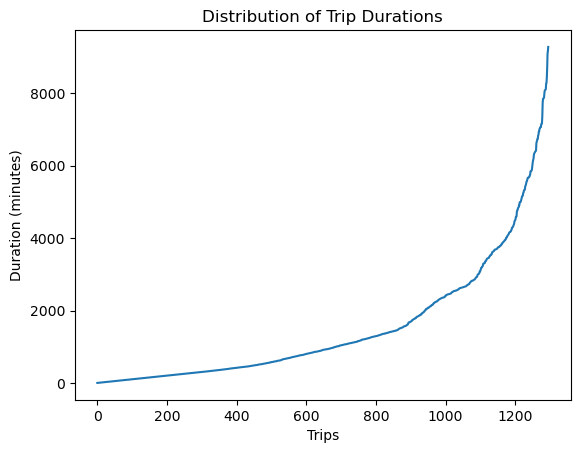

```python
"""Lets plot a line graph between start_time, end_time and difference for trip_id"""
# Create a DataFrame with the time difference
df_difference = df.copy()
df_difference["difference"] = (df["end_time"] - df["start_time"]).apply(lambda x: x.total_seconds() / 60) #convert to minutes
df_difference = df_difference.sort_values("difference") #sort in ascending order

# Plotting the unique time differences using line graph
plt.plot(df_difference["difference"].unique())

# Adding labels and headings
plt.title('Distribution of Trip Durations')
plt.xlabel('Trips')
plt.ylabel('Duration (minutes)')

# Display the plot
plt.show()
```

```python
print(df_difference["difference"].min())
print(df_difference["difference"].max())
```

```
1.0
9283.0
```

The above output reveals that the shortest trip duration is 1 minute, while the longest trip spans approximately 6.45 days.Examining the 'duration' column, it represents the actual time the vehicle is driven in minutes. Occasionally, the duration is considerably shorter than the difference between 'start_time' and 'end_time,' indicating periods when the bike was stationary for a significant duration. The idle time of the bike can be determined using the calculation below.

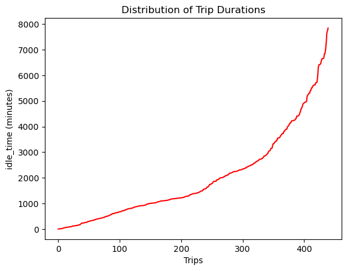

```python
df["difference"] = df["end_time"] - df["start_time"]
df["difference"] = df["difference"].apply(lambda x:x.total_seconds()/60) #convert to minutes
df["idle_time"] = df["difference"] - df["duration"]

# Plotting the unique time differences using line graph
plt.plot(df["idle_time"].sort_values().unique(), color="r")

# Adding labels and headings
plt.title('Distribution of Trip Durations')
plt.xlabel('Trips')
plt.ylabel('idle_time (minutes)')

# Display the plot
plt.show()
```

```python
print(df["idle_time"].max())
```

```
7843.0
```

It can be observed that the maximum idle time is 7843 minutes which is approximately 5.5 days.Lets consider that 60 minutes buffer for calculating the number of trips that are idle

```python
df_idle = df[df["idle_time"] > 60]
print(len(df_idle))
df.drop(columns=["difference","idle_time"], inplace=True) #drop the columns used for calculation
```

```
464
```

This indicates that among the 92122 trips, there are 464 instances where the idle time exceeds 60 minutes, suggesting that these vehicles could have been utilized for additional trips during those periods.

###### Multiple bike_ids

Upon reviewing the 'bike_id' column, it becomes apparent that the same bike_id is associated with multiple trip_ids, although not concurrently. Take, for instance, the scenario where bike_id = 5717. This is logical, considering that a single bike cannot be engaged in multiple trips simultaneously.

```python
df_bike_id = df_2[df_2["bike_id"] == 5717]
df_bike_id = df_bike_id.sort_values("start_time")
print(df_bike_id[["trip_id", "start_time", "end_time"]])
```

```
         trip_id          start_time            end_time
4856   124979043 2019-07-06 09:47:00 2019-07-06 10:27:00
6348   125085564 2019-07-08 07:01:00 2019-07-08 07:07:00
6424   125090419 2019-07-08 08:42:00 2019-07-08 08:47:00
8577   125226354 2019-07-10 15:13:00 2019-07-10 15:27:00
8611   125228286 2019-07-10 15:43:00 2019-07-10 16:07:00
10888  125386698 2019-07-13 09:44:00 2019-07-13 09:56:00
10932  125390788 2019-07-13 11:01:00 2019-07-13 11:18:00
11351  125412574 2019-07-13 18:52:00 2019-07-13 19:01:00
12493  125501065 2019-07-15 09:30:00 2019-07-15 09:36:00
13136  125530925 2019-07-15 19:43:00 2019-07-15 20:15:00
13262  125541621 2019-07-15 22:34:00 2019-07-15 23:16:00
13450  125556601 2019-07-16 08:21:00 2019-07-16 08:48:00
14946  125639062 2019-07-17 17:01:00 2019-07-17 17:14:00
16655  125739819 2019-07-19 11:54:00 2019-07-19 12:06:00
35976  126914460 2019-08-08 13:44:00 2019-08-08 15:14:00
46004  127486994 2019-08-18 10:36:00 2019-08-18 10:58:00
50667  127712035 2019-08-22 08:47:00 2019-08-22 08:51:00
53509  127850893 2019-08-24 16:03:00 2019-08-24 16:06:00
53821  127861865 2019-08-24 19:49:00 2019-08-24 20:12:00
75340  129087973 2019-09-14 15:23:00 2019-09-14 15:48:00
79270  129339636 2019-09-18 12:18:00 2019-09-18 15:37:00
83949  129558177 2019-09-22 17:43:00 2019-09-22 17:45:00
86010  129748367 2019-09-24 16:55:00 2019-09-25 00:04:00
```

###### Passholder types and plan duration

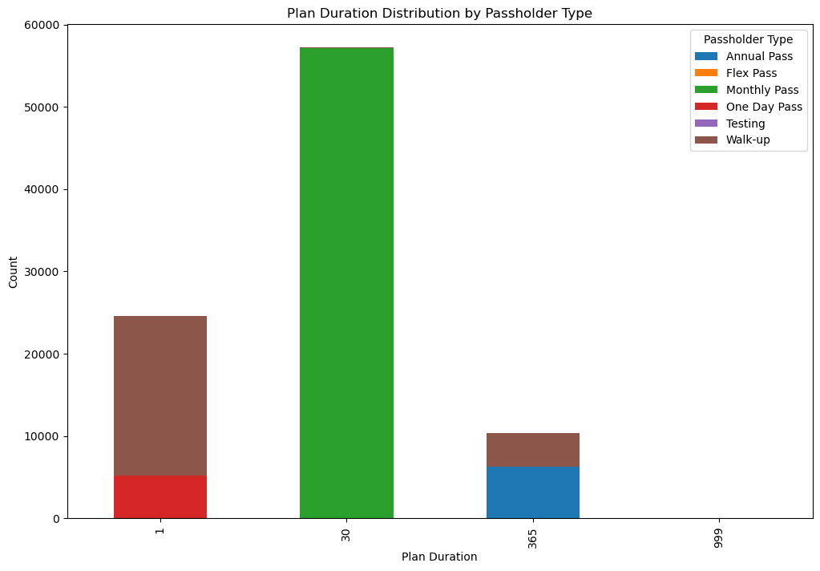

```python
count_of_passholder = df_2.groupby(['plan_duration','passholder_type']).size().reset_index()

# Sorting the DataFrame for better visualization
count_of_passholder = count_of_passholder.sort_values(by=['plan_duration', 'passholder_type'])

# Pivot the DataFrame
count_of_passholder_pivot = count_of_passholder.pivot(index='plan_duration', columns='passholder_type', values=0).fillna(0)

# Plotting the bar graph
fig, ax = plt.subplots(figsize=(12, 8))

# Plotting each passholder type for every plan duration as stacked bar graph
count_of_passholder_pivot.plot(kind='bar', stacked=True, ax=ax)

ax.set_xlabel('Plan Duration')
ax.set_ylabel('Count')
ax.set_title('Plan Duration Distribution by Passholder Type')
ax.legend(title='Passholder Type')

plt.show()
```

Insights from stacked bar graph:

- Passengers opting for a plan duration of 30 days are limited to the monthly pass as their only option.
- For passengers with a one-day pass, there is a higher occurrence of walk-ups compared to one-day pass.
- There are only 46 entries with a plan duration of 999, categorized as "Testing" in the passholder type. These entries may be considered for removal due to their limited count.

```python
df_2 = df_2[df_2["passholder_type"] != "Testing"] #drop Testing passholder_type
```

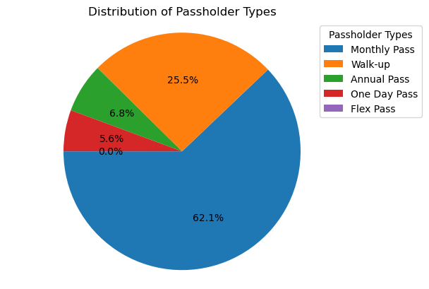

```python
# Count the occurrences of each passholder type
passholder_counts = df_2['passholder_type'].value_counts()

# Plotting the pie chart
fig, ax = plt.subplots()
wedges, texts, autotexts = ax.pie(passholder_counts, autopct='%1.1f%%', startangle=180)

# Adding a legend
ax.legend(wedges, passholder_counts.index, title='Passholder Types', loc='upper right', bbox_to_anchor=(1.2, 1))

# Set aspect ratio to be equal
ax.axis('equal')

# Display the pie chart
plt.title('Distribution of Passholder Types')
plt.show()
```

Insights from pie-chart:

- More than half of the total passholders are Monthly pass holders.
- Approximately 25% of passholders opt for walk-up passes.
- Count of flex pass is very negligible.
- This indicates a preference for monthly passes over annual passes, while a considerable number of individuals choose walk-up passes over one day passes.

##### Correlation between different features

Analyzing the correlation between features stands as a pivotal phase in data scrutiny and modeling. This process yields valuable insights into the connections among variables, allowing for the detection of patterns and interdependencies within the dataset. The magnitude and direction of correlation serve as guiding factors in comprehending how alterations in one variable can impact another, simplifying the interpretation of data dynamics. This insight proves especially advantageous in machine learning, directing the choice of influential features for model training. Moreover, correlation analysis facilitates a thorough examination of multivariate scenarios, contributing to a holistic understanding of intricate systems. It functions as a tool for validating assumptions in statistical models, ensuring adherence to model requirements.

The Matplotlib command "matshow()" [5] is employed to depict a matrix as a colormap. The code calculates the correlation matrix for numerical columns in the dataframe, showcasing pairwise correlations. The resulting heatmap, generated, employs colors to signify correlation strengths.

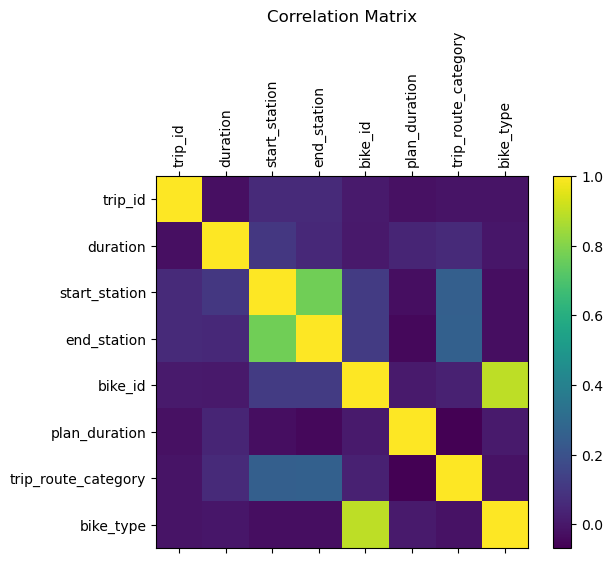

```python
f = plt.figure()

# Displaying the correlation matrix as an image
plt.matshow(df_2.corr(), fignum=f.number)

# Setting x-axis ticks and labels
plt.xticks(range(df_2.select_dtypes(['number']).shape[1]), df_2.select_dtypes(['number']).columns, fontsize=10, rotation=90)

# Setting y-axis ticks and labels
plt.yticks(range(df_2.select_dtypes(['number']).shape[1]), df_2.select_dtypes(['number']).columns, fontsize=10)

# Adding a colorbar for reference
cb = plt.colorbar()
cb.ax.tick_params(labelsize=10)

# Adding a title to the plot
plt.title('Correlation Matrix', fontsize=12)

# Displaying the plot
plt.show()
```

Insights from correlation matrix:

- Feature "duration" and "bike_type" with "trip_id" is least correlated
- Feature "bike_id" and "bike_type" are highly correlated
- Feature "trip_route_category" and "plan_duration" also show low correlation

##### Outlier identification

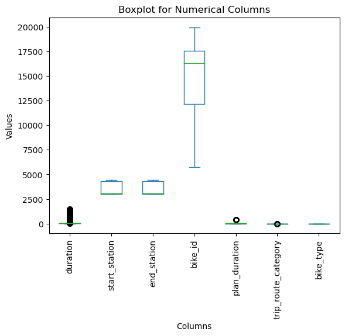

```python
# Plotting boxplot for numerical columns in the DataFrame df_2 with a specified title
plt.figure()
ax = df_2[df_2.columns[1:]].plot(kind='box', title='Boxplot for Numerical Columns')
plt.xticks(fontsize=10, rotation=90)
plt.xlabel('Columns')
plt.ylabel('Values')

# Displaying the plot
plt.show()
```

###### Insights from boxplot:

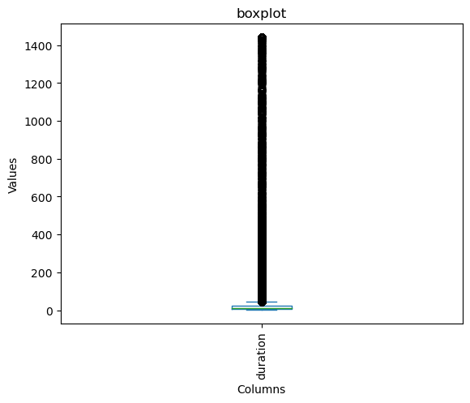

```python
#Plot boxplot for column "duration"
plt.figure()
ax = df_2["duration"].plot(kind='box', title='boxplot',)
plt.xticks(fontsize=10, rotation=90)
plt.xlabel('Columns')
plt.ylabel('Values')
```

```python
print(len(df_2[df_2["duration"] > 100]))
```

```
3461
```

While the presence of numerous outliers in the 'duration' column suggests their removal, a deeper examination of the data reveals that the 'duration' information might be crucial for subsequent analysis. This is evident from earlier comparisons involving duration. Further scrutiny and comprehension of the data will help determine whether to retain or eliminate this information.

##### Weekly and daily bike count

The code endeavors to generate visualizations illustrating the count of unique bikes on a weekly and daily basis. Utilizing Python's explode function on the 'week' column, where each row contains a list of weeks, enables the transformation of each list into individual rows. This process ensures the duplication of other column values and aims to provide a clearer representation of the data in terms of weekly bike counts.

plt.subplots() from matplotlib is used to initialize the creation of a figure with two subplots arranged vertically. The parameters 2, 1 indicate the configuration of having two subplots in a single column. The resulting ax1 and ax2 variables represent the axes for the two subplots, providing a framework for displaying diverse visualizations or data presentations within a unified figure.

```python
# Extract week from start_time and end_time
df_bike_id = df_2[["start_time","end_time","bike_id"]]
df_bike_id['week_1'] = df_2['start_time'].dt.week
df_bike_id['week_2'] = df_2['end_time'].dt.week

#Extract weeks between start and end week
df_bike_id['week'] = pd.DataFrame({
    'week': df_bike_id.apply(lambda row: list(range(row['week_1'], row['week_2'] + 1)), axis=1)})
df_bike_id = df_bike_id.explode('week').reset_index(drop=True)

# Count unique bikes per week
weekly_bike_counts = df_bike_id.groupby(['week'])['bike_id'].nunique()
```

```python
# Extract day from start_time and end_time
df_bike_id = df_2[["start_time","end_time","bike_id"]]
df_bike_id['start_day'] = df_2['start_time'].dt.date
df_bike_id['end_day'] = df_2['end_time'].dt.date

#Extract days between start and end week
df_bike_id["day"] = pd.DataFrame({
    'day': df_bike_id.apply(lambda row: pd.date_range(row['start_day'], row['end_day']+timedelta(1)).tolist(), axis=1)})
df_bike_id = df_bike_id.explode('day').reset_index(drop=True)

# Count unique bikes per day
daily_bike_counts = df_bike_id.groupby(['day'])['bike_id'].nunique()
```

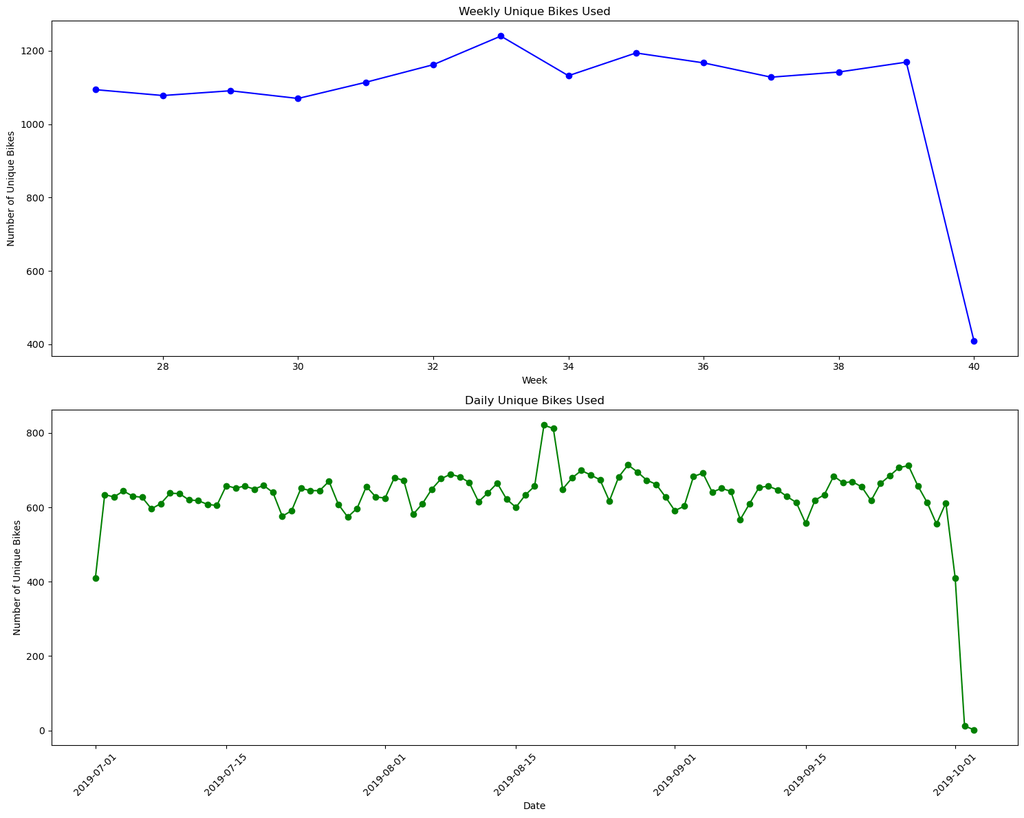

```python
# Plotting both graphs as subplots
fig, (ax1, ax2) = plt.subplots(2, 1, figsize=(15, 12))

# Weekly Unique Bikes Used
ax1.plot(weekly_bike_counts.index, weekly_bike_counts.values, marker='o', linestyle='-', color='b')
ax1.set_xlabel('Week')
ax1.set_ylabel('Number of Unique Bikes')
ax1.set_title('Weekly Unique Bikes Used')

# Daily Unique Bikes Used
ax2.plot(daily_bike_counts.index, daily_bike_counts.values, marker='o', linestyle='-', color='g')
ax2.set_xlabel('Date')
ax2.set_ylabel('Number of Unique Bikes')
ax2.set_title('Daily Unique Bikes Used')
ax2.tick_params(axis='x', rotation=45)

# Adjust layout to prevent overlap
plt.tight_layout()

# Display the subplots
plt.show()
```

```python
df_2.head()
```

|  | trip_id | duration | start_time | end_time | start_station | end_station | bike_id | plan_duration | trip_route_category | passholder_type | bike_type |
| --- | --- | --- | --- | --- | --- | --- | --- | --- | --- | --- | --- |
| 0 | 124657107 | 5 | 2019-07-01 00:04:00 | 2019-07-01 00:09:00 | 4312 | 4410 | 6168 | 30 | 1 | Monthly Pass | 1 |
| 1 | 124657587 | 9 | 2019-07-01 00:07:00 | 2019-07-01 00:16:00 | 3066 | 3066 | 17584 | 30 | 2 | Monthly Pass | 3 |
| 2 | 124658068 | 5 | 2019-07-01 00:20:00 | 2019-07-01 00:25:00 | 4410 | 4312 | 18920 | 30 | 1 | Monthly Pass | 3 |
| 3 | 124659747 | 20 | 2019-07-01 00:44:00 | 2019-07-01 01:04:00 | 3045 | 4275 | 6016 | 1 | 1 | Walk-up | 1 |
| 4 | 124660227 | 27 | 2019-07-01 00:44:00 | 2019-07-01 01:11:00 | 3035 | 3049 | 5867 | 30 | 1 | Monthly Pass | 1 |

The simplified dataset provided above is suitable for in-depth analysis. It represents trip data spanning July, August, and September of the year 2019. Passengers have the option to choose between one-way or round-trip journeys, with passholder types including direct walk-ins or those opting for daily, monthly, or yearly plans. Bikes are operational multiple times a day, with no schedule conflicts, and they come in various types, such as standard, electric, or smart.

# Task 2 - Seed Shape Analysis

#### LOAD DATAFRAME

The CSV file "seeds.csv" needs to be located in the current working directory.

```python
df_seed = pd.read_csv("seeds.csv")
```

```python
print(df_seed.info()) #basic understanding of data
```

```
<class 'pandas.core.frame.DataFrame'>
RangeIndex: 210 entries, 0 to 209
Data columns (total 7 columns):
 #   Column         Non-Null Count  Dtype
---  ------         --------------  -----
 0   area           210 non-null    float64
 1   perimeter      210 non-null    float64
 2   compactness    210 non-null    float64
 3   length         210 non-null    float64
 4   width          210 non-null    float64
 5   asymmetry      210 non-null    float64
 6   groove_length  210 non-null    float64
dtypes: float64(7)
memory usage: 11.6 KB
None
```

It can be observed that df_seed has 210 entries, indexed from 0 to 209. It encompasses seven columns: 'area,' 'perimeter,' 'compactness,' 'length,' 'width,' 'asymmetry,' and 'groove_length.' All these columns exclusively store numerical values with precision, given their 'float64' data type. The 'non-null count' for each column is uniformly 210, signifying the absence of missing or null values throughout the dataset.

```python
df_seed.drop_duplicates(inplace = True) #drop duplicates
print(len(df_seed))
```

```
210
```

Even with the removal of duplicate values, the count of rows in the df_seed DataFrame remains unchanged, confirming the absence of any duplicated entries.

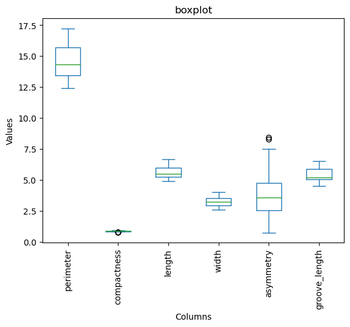

```python
# Plot boxplot
plt.figure()
ax = df_seed[df_seed.columns[1:]].plot(kind='box', title='boxplot',)
plt.xticks(fontsize=10, rotation=90)
plt.xlabel('Columns')
plt.ylabel('Values')

# Display the plot
plt.show()
```

##### Insights from boxplot:

- Outliers are apparent in the features "compactness" and "asymmetry."
- While these values could be removed, caution is exercised to preserve data integrity, considering the dataset's small size. Dropping values might impact the results, and alternative approaches will be explored.

#### PRIMARY MODEL 1 - KMEANS CLUSTERING

K-means clustering stands out as a prevalent unsupervised machine learning technique employed for segmenting an unlabeled, multi-dimensional dataset into distinct and non-overlapping subgroups or clusters. The primary objective of the algorithm is to organize data points into clusters based on their similarity, with the goal of minimizing within-cluster variance and maximizing between-cluster variance.

The algorithm operates on the principle that an "optimal" cluster adheres to certain criteria:

- The cluster center is determined by calculating the arithmetic mean of the features of all the points within the cluster.
- Each data point within a cluster is closer to its own cluster center than to the centers of other clusters.

This model is characterized by its simplicity, offering a straightforward conceptualization of what constitutes an ideal cluster.

Selecting a suitable value for K is crucial, and the algorithm's effectiveness can be influenced by the initial positioning of centroids. Enhancing robustness can be achieved by conducting multiple runs with diverse initializations. The code implemented shows the best k value for kmeans clustering. The algorithm's objective is to minimize the within-cluster variance, and with K=2, it tends to create binary separations. This binary nature may not capture nuanced patterns in the data. So we will consider values from 3 to 15. After 15, the silhoutte score is dropping.

For the primary models, silhouette score is used as test of efficency for clustering. Silhouette score gauges the clarity and distinctiveness of clusters in the dataset. Spanning from -1 to 1, the silhouette score signifies the quality of clustering, with higher values indicating that an object aligns well with its assigned cluster and is less aligned with neighboring clusters. This metric considers both the cohesion within clusters and the separation between clusters, offering a comprehensive evaluation of clustering performance.

```python
# List to store the metric value given different K values
C_S = []
value_k=3
highest_value = 0

# Range of the different values of K to analyse
K = range(3, 15)

# Iterate over K
for k in K:
    kmeans = KMeans(n_clusters=k)
    kmeans.fit(df_seed)
    score = silhouette_score(df_seed, kmeans.labels_)
    C_S.append([k, score])
    if highest_value < score:
        value_k = k
        highest_value = score

C_S
```

```
[[3, 0.47193375399373283],
 [4, 0.41252808179415285],
 [5, 0.3588387879858586],
 [6, 0.36795590421414476],
 [7, 0.35289709241059],
 [8, 0.36160094580589125],
 [9, 0.35648373162058716],
 [10, 0.3543213556814523],
 [11, 0.3374966725931678],
 [12, 0.3254218127070746],
 [13, 0.3338871182255582],
 [14, 0.3290721948882786]]
```

```python
print(f"k = {value_k}") #print the k value for highest silhouette_score
print(f"higest silhouette_score = {highest_value}") #highest silhouette_score
```

```
k = 3
higest silhouette_score = 0.47193375399373283
```

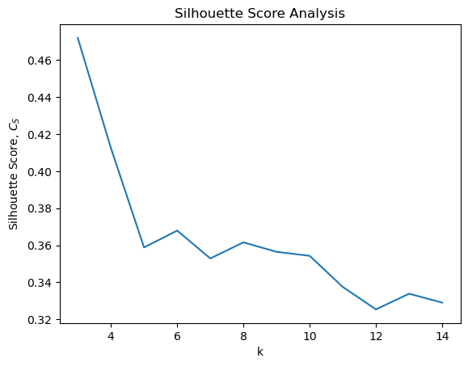

```python
# Extract the second element (silhouette score) from each list in C_S
C_S_1 = [x[1] for x in C_S]

# Plotting the Silhouette Score analysis
plt.plot(K, C_S_1)
plt.xlabel('k')  # X-axis label
plt.ylabel(r'Silhouette Score, $C_S$')  # Y-axis label with LaTeX formatting
plt.title('Silhouette Score Analysis')  # Title of the plot
plt.show()  # Display the plot
```

```python
kmeans = KMeans(n_clusters=value_k)

# Train the model
kmeans.fit(df_seed)
df_seed["Cluster_k_means"] = kmeans.predict(df_seed)
```

```python
df_seed.head()
```

|  | area | perimeter | compactness | length | width | asymmetry | groove_length | Cluster_k_means |
| --- | --- | --- | --- | --- | --- | --- | --- | --- |
| 0 | 15.26 | 14.84 | 0.871 | 5.763 | 3.312 | 2.221 | 5.220 | 2 |
| 1 | 14.88 | 14.57 | 0.881 | 5.554 | 3.333 | 1.018 | 4.956 | 2 |
| 2 | 14.29 | 14.09 | 0.905 | 5.291 | 3.337 | 2.699 | 4.825 | 2 |
| 3 | 13.84 | 13.94 | 0.895 | 5.324 | 3.379 | 2.259 | 4.805 | 2 |
| 4 | 16.14 | 14.99 | 0.903 | 5.658 | 3.562 | 1.355 | 5.175 | 2 |

#### PRIMARY MODEL 2 - GAUSSIAN MIXTURE MODELS (GMM) CLUSTERING

Gaussian Mixture Models (GMM) serve as a probabilistic model employed for both clustering and density estimation within the field of machine learning. In contrast to the K-means algorithm, GMM operates under the assumption that the dataset is generated through a mixture of various Gaussian distributions, each characterized by unknown parameters. Each Gaussian component within the GMM signifies a distinct cluster within the dataset. Essentially, GMMs provide a means to represent datasets where observations may originate from a combination of multiple underlying probability distributions.

Noteworthy Features:

- Gaussian Mixture Models extend the concepts of K-means, introducing a probabilistic approach that can better capture the complexities present in various applications.
- Unlike K-means, which lacks a probabilistic framework, GMM allows for a more nuanced understanding of the likelihood associated with each data point's cluster assignment.
- This becomes particularly valuable in scenarios where clusters closely align, and their areas of influence overlap, making it challenging for traditional methods like K-means to provide accurate assessments.

In Gaussian Mixture Models (GMM), the parameter n_components defines the quantity of Gaussian components or clusters within the mixture model. It plays a pivotal role in deciding the number of Gaussian distributions employed to portray the underlying structure of the dataset. This is very critical value and If the number of components (n_components) in a Gaussian Mixture Model (GMM) is set to 2, it may lead to overfitting if the data doesn't naturally exhibit two distinct clusters or Gaussian distributions. So we will vary values from 3 to 15. Silhouette score is dropping after 15

```python
# List to store the metric value given different component values
C_V = []
value_c=3
highest_value_2 = 0
# Range of the different values of K to analyse
K = range(3, 15)

# Iterate over K
for k in K:
    gmm = GMM(n_components=k, random_state=568).fit(df_seed[df_seed.columns[:-1]])
    labels = gmm.predict(df_seed[df_seed.columns[:-1]])
    score = silhouette_score(df_seed[df_seed.columns[:-1]], labels)
    C_V.append([k, score])
    if highest_value_2 < score:
        value_c = k
        highest_value_2 = score

C_V
```

```
[[3, 0.4505982254703574],
 [4, 0.338263875944015],
 [5, 0.28459553937311394],
 [6, 0.3120775551045929],
 [7, 0.2754278698821206],
 [8, 0.2427706961905524],
 [9, 0.30132437353756375],
 [10, 0.25811985439320473],
 [11, 0.2589405913429975],
 [12, 0.2641569296608018],
 [13, 0.22967120576776387],
 [14, 0.25958744694766306]]
```

```python
print(f"k = {value_c}") #print the n_component value for highest silhouette_score
print(f"higest silhouette_score = {highest_value_2}") #highest silhouette_score
```

```
k = 3
higest silhouette_score = 0.4505982254703574
```

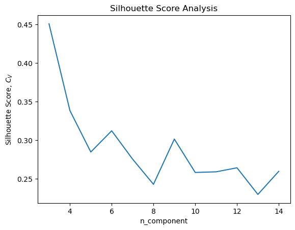

```python
# Extract the second element (silhouette score) from each list in C_V
C_V_1 = [x[1] for x in C_V]

# Plotting the Silhouette Score analysis
plt.plot(K, C_V_1)
plt.xlabel('n_component') # X-axis label
plt.ylabel(r'Silhouette Score, $C_V$') # Y-axis label with LaTeX formatting
plt.title('Silhouette Score Analysis') # Title of the plot
plt.show() # Display the plot
```

```python
# Initialise and fit the GMM
gmm = GMM(n_components=value_c, random_state=568).fit(df_seed[df_seed.columns[:-1]])
df_seed["Cluster_gmm"] = gmm.predict(df_seed[df_seed.columns[:-1]])
```

```python
df_seed.head() #display the results
```

|  | area | perimeter | compactness | length | width | asymmetry | groove_length | Cluster_k_means | Cluster_gmm |
| --- | --- | --- | --- | --- | --- | --- | --- | --- | --- |
| 0 | 15.26 | 14.84 | 0.871 | 5.763 | 3.312 | 2.221 | 5.220 | 2 | 0 |
| 1 | 14.88 | 14.57 | 0.881 | 5.554 | 3.333 | 1.018 | 4.956 | 2 | 0 |
| 2 | 14.29 | 14.09 | 0.905 | 5.291 | 3.337 | 2.699 | 4.825 | 2 | 0 |
| 3 | 13.84 | 13.94 | 0.895 | 5.324 | 3.379 | 2.259 | 4.805 | 2 | 0 |
| 4 | 16.14 | 14.99 | 0.903 | 5.658 | 3.562 | 1.355 | 5.175 | 2 | 0 |

#### EVALUATION OF PRIMARY MODELS

Below code employs Pandas' scatter_matrix function for both models to create a matrix of scatter plots for the columns in the DataFrame df_seed. It uses transparency (alpha=0.9) for better visualization and assigns colors to points based on the categorical codes of the 'Cluster_k_means' column. The resulting plots reveal relationships between variables and showcase the clustering results.

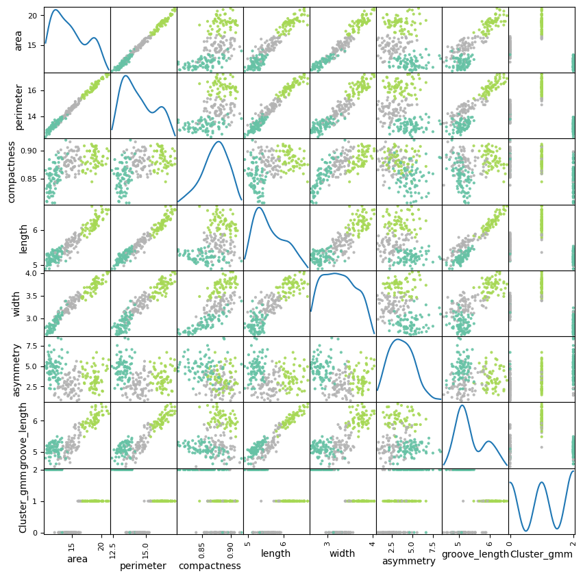

```python
df_seed['Cluster_k_means'] = df_seed['Cluster_k_means'].astype('category')

# Create a scatter matrix
scatter_matrix(df_seed, alpha=0.9, figsize=(10, 10), diagonal='kde', c=df_seed['Cluster_k_means'].cat.codes, cmap='Set2')

plt.show()
```

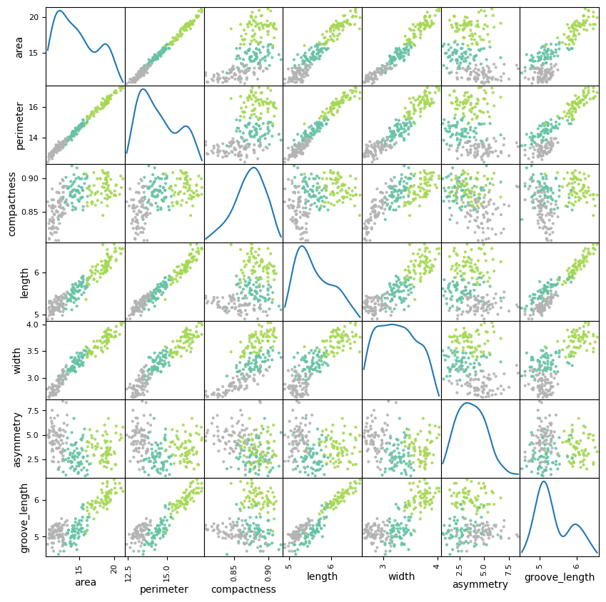

```python
df_seed['Cluster_gmm'] = df_seed['Cluster_gmm'].astype('category')

# Create a scatter matrix
scatter_matrix(df_seed, alpha=0.9, figsize=(10, 10), diagonal='kde', c=df_seed['Cluster_gmm'].cat.codes, cmap='Set2')

plt.show()
```

In both scatter plots, the features exhibit distinct clusters, and the data follows a clear trend along a straight line. As the x-values increase, there is a corresponding increase in the y-values, indicating a linear relationship between the variables.

The Davies-Bouldin Index is calculated as the average similarity between clusters, considering both their internal cohesion and external separation. The formula involves comparing the dispersion within each cluster and the distance between different clusters. The scikit-learn library provides the davies_bouldin_score function for computing this index. A lower Davies-Bouldin score, close to 0, signifies clearer separation and distinct characteristics among clusters, indicating a more optimal clustering solution.

```python
print(davies_bouldin_score(df_seed[df_seed.columns[:-2]], df_seed["Cluster_gmm"]))
print(davies_bouldin_score(df_seed[df_seed.columns[:-2]], df_seed["Cluster_k_means"]))
```

```
0.7791943296466135
0.7533141051758455
```

###### Result

Looking at Davies-Bouldin Index as well as silhouette score, we can see that KMeans clustering is better option than GMM clustering.

#### LOCATE A COPY AND DIFFERENTIATE THE DATASET

```python
#Read seeds_dataset.txt with delimiter as whitespace along with header
df_seed_og = pd.read_csv("seeds_dataset.txt", delim_whitespace = True, header=None, index_col=None, names=list(df_seed.columns[:-2])+["cluster"])
```

```python
print(df_seed_og.head())
```

```
    area  perimeter  compactness  length  width  asymmetry  groove_length  \
0  15.26      14.84       0.8710   5.763  3.312      2.221          5.220
1  14.88      14.57       0.8811   5.554  3.333      1.018          4.956
2  14.29      14.09       0.9050   5.291  3.337      2.699          4.825
3  13.84      13.94       0.8955   5.324  3.379      2.259          4.805
4  16.14      14.99       0.9034   5.658  3.562      1.355          5.175

   cluster
0        1
1        1
2        1
3        1
4        1
```

Difference between seed.csv and seed_dataset.txt:

Improvement in evaluation:

- Combination of metrics that capture different aspects of clustering quality.
- Use labelled data for evaluation
- Hyperparameter Tuning and feature reduction[1]
- Ensemble or hierarchial methods for clustering
- Handle Outliers
- Additional Data Preprocessing

With labeled data available, we can employ this information to apply a classification model.

#### RE-EVALUTION

```python
df_seed_og['compactness'] = df_seed_og['compactness'].round(3) #round upto 3 decimals for matching values with df_seed
```

```python
merge_df = pd.merge(df_seed_og, df_seed, on = list(df_seed.columns[:-2]), how= "inner") #merge data to get all values together
```

```python
print(merge_df.head())
```

```
    area  perimeter  compactness  length  width  asymmetry  groove_length  \
0  15.26      14.84        0.871   5.763  3.312      2.221          5.220
1  14.88      14.57        0.881   5.554  3.333      1.018          4.956
2  14.29      14.09        0.905   5.291  3.337      2.699          4.825
3  16.14      14.99        0.903   5.658  3.562      1.355          5.175
4  14.38      14.21        0.895   5.386  3.312      2.462          4.956

   cluster Cluster_k_means Cluster_gmm
0        1               2           0
1        1               2           0
2        1               2           0
3        1               2           0
4        1               2           0
```

The Rand Index serves as a metric within clustering algorithms, gauging the correspondence between the actual labels and those predicted by the algorithm[3] It evaluates the agreement level between the clustering outcomes and the true groupings in the dataset. Ranging from 0 to 1, the Rand Index score signifies no similarity at 0 and perfect alignment at 1. Notably, it is applicable not only in supervised settings but also in unsupervised scenarios, offering flexibility for cluster label comparisons. An additional application includes its role as a foundational component for constructing a Consensus Index, aiding in the selection of clustering models.

Key Attributes:

- No assumptions about clustering structure or precise labels are imposed.
- The Rand Index explores various permutations of potential integer labels.

```python
rand_score(merge_df["cluster"], merge_df["Cluster_k_means"])
```

```
0.8706960248263632
```

```python
rand_score(merge_df["cluster"], merge_df["Cluster_gmm"])
```

```
0.9088222255061327
```

###### Result

Using this new evaluation technique, we can see that GMM clustering is performing better than Kmeans clustering

#### SECONDARY MODEL AND EVALUATION

Additionally, the evaluation can be seen with multiple metrices such as accuracy, precicion, recall, confusion matrix

```python
# X contains the features, and y contains the target variable
# Split the data into training and testing sets
X_train, X_test, y_train, y_test = train_test_split(df_seed_og[df_seed_og.columns[:-1]], df_seed_og["cluster"], test_size=0.2, random_state=42)

# Create a Support Vector Machine model
model = SVC(kernel='linear', C=1E6)  # Use a linear kernel for simplicity, you can try other kernels as well

# Train the model on the training set
model.fit(X_train, y_train)

# Make predictions on the test set
y_pred = model.predict(X_test)

# Evaluate the model
accuracy = accuracy_score(y_test, y_pred)
conf_matrix = confusion_matrix(y_test, y_pred)
classification_rep = classification_report(y_test, y_pred)

# Print the results
print(f"Accuracy: {accuracy}")
print(f"Confusion Matrix:\n{conf_matrix}")
print(f"Classification Report:\n{classification_rep}")
```

```
Accuracy: 0.9761904761904762
Confusion Matrix:
[[11  0  0]
 [ 0 14  0]
 [ 1  0 16]]
Classification Report:
              precision    recall  f1-score   support

           1       0.92      1.00      0.96        11
           2       1.00      1.00      1.00        14
           3       1.00      0.94      0.97        17

    accuracy                           0.98        42
   macro avg       0.97      0.98      0.98        42
weighted avg       0.98      0.98      0.98        42
```

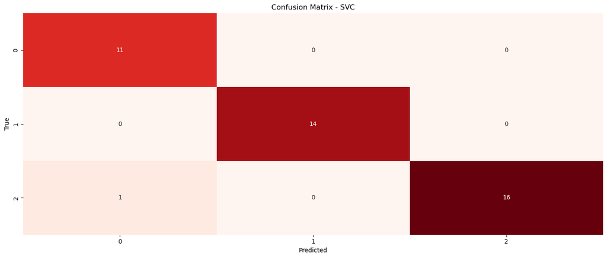

```python
# Confusion Matrix and Classification Report
plt.figure(figsize=(14, 6))

sns.heatmap(conf_matrix, annot=True, fmt="d", cmap="Reds", cbar=False)
plt.title(f'Confusion Matrix - SVC')
plt.xlabel('Predicted')
plt.ylabel('True')

plt.tight_layout()
plt.show()
```

##### Result

By employing the heatmap visualization from Seaborn, it becomes evident that the model accurately predicts nearly all values, achieving an impressive accuracy of 98%. This outstanding performance positions it as the top-performing model within the given dataset.

# REFERENCES

[1] S. Lu et al., "Clustering Method of Raw Meal Composition Based on PCA and Kmeans," 2018 37th Chinese Control Conference (CCC), Wuhan, China, 2018, pp. 9007-9010, doi: 10.23919/ChiCC.2018.8482823.

[2] R. Dubin et al., "Hybrid Clustered Peer-Assisted DASH-SVC System," 2015 IEEE International Conference on Computer and Information Technology; Ubiquitous Computing and Communications; Dependable, Autonomic and Secure Computing; Pervasive Intelligence and Computing, Liverpool, UK, 2015, pp. 1651-1656, doi: 10.1109/CIT/IUCC/DASC/PICOM.2015.249.

[3] L. Petricioli, K. Skračić, J. Petrović and P. Pale, "Exploring Pre-scoring Clustering for Short Answer Grading," 2023 46th MIPRO ICT and Electronics Convention (MIPRO), Opatija, Croatia, 2023, pp. 1567-1571, doi: 10.23919/MIPRO57284.2023.10159981.

[4] https://pandas.pydata.org/docs/reference/api/pandas.pivot_table.html

[5] https://matplotlib.org/stable/api/_as_gen/matplotlib.pyplot.matshow.html